# Лабораторная работа №2

Простые сети в GNS3. Анализ трафика

Акунаева Антонина Эрдниевна

Российский университет дружбы народов, Москва, Россия

2026-09-26

# Информация

## Докладчик

- Акунаева Антонина Эрдниевна
- студент ФФМиЕН, НПИбд-02-24
- Российский университет дружбы народов
- 1032240492@rudn.ru
- https://github.com/Akuxee

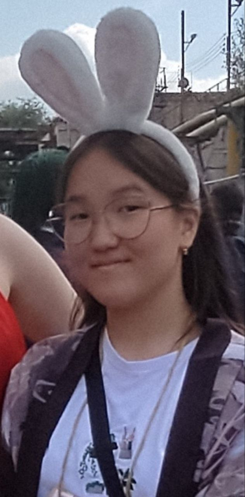

# Цели и задачи

- Построение простейших моделей сети на базе коммутатора и маршрутизаторов FRR и VyOS в GNS3, анализ трафика посредством Wireshark.

**2.3.1. Моделирование простейшей сети на базе коммутатора в GNS3**

1. Построить в GNS3 топологию сети, состоящей из коммутатора Ethernet и двух оконечных устройств (персональных компьютеров).
2. Задать оконечным устройствам IP-адреса в сети 192.168.1.0/24. Проверить связь.

**2.3.2. Анализ трафика в GNS3 посредством Wireshark**

1. С помощью Wireshark захватить и проанализировать ARP-сообщения.
2. С помощью Wireshark захватить и проанализировать ICMP-сообщения.

**2.3.3. Моделирование простейшей сети на базе маршрутизатора FRR в GNS3**

1. Построить в GNS3 топологию сети, состоящей из маршрутизатора FRR, коммутатора Ethernet и оконечного устройства.
2. Задать оконечному устройству IP-адрес в сети 192.168.1.0/24.
3. Присвоить интерфейсу маршрутизатора адрес 192.168.1.1/24
4. Проверить связь.

**2.3.4. Моделирование простейшей сети на базе маршрутизатора VyOS в GNS3**

1. Построить в GNS3 топологию сети, состоящей из маршрутизатора VyOS, коммутатора Ethernet и оконечного устройства.
2. Задать оконечному устройству IP-адрес в сети 192.168.1.0/24.
3. Присвоить интерфейсу маршрутизатора адрес 192.168.1.1/24
4. Проверить связь

# Материалы и методы

- Linux Fedora Workstation (Markdown)
- Oracle VirtualBox 7.2.16
- GNS3 VM 3.0.6
- GNS3 3.0.6
- Wireshark

# Выполнение лабораторной работы

## Тология простейшей сети в GNS3 и задание адреса PC-1

[figure not shown]

## Задание адреса PC-2

[figure not shown]

## Проверка соединений

[figure not shown]

## Анализатор трафика Wireshark

[figure not shown]

## Отправление эхо-запросов в разных модах

[figure not shown]

## Фильтрация пакетов по ARP-протоколу

[figure not shown]

## Фильтрация пакетов по ICMP-протоколу

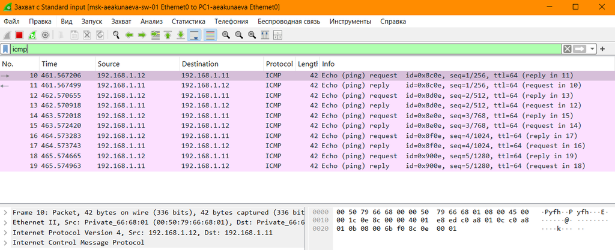

## Фильтрация пакетов по UDP-протоколу

[figure not shown]

## Фильтрация пакетов по TCP-протоколу

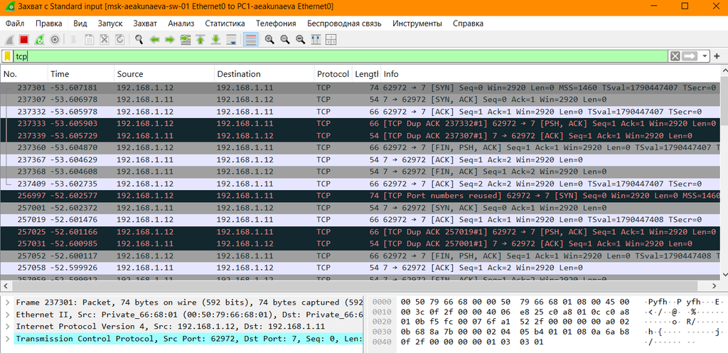

## Проект 2 в GNS3

[figure not shown]

## Настройка IP-адресации устройств

[figure not shown]

## Проверка подключения соединения

[figure not shown]

## Проект 3 в GNS3

[figure not shown]

## Настройка устройств проекта 3

[figure not shown]

## Проверка и сохранение изменений конфигурации маршрутизатора VyOS

[figure not shown]

## Проверка соединения в Wireshark

[figure not shown]

# Выводы

Я получила навыки построения простейших моделей сети на базе коммутатора и маршрутизаторов FRR и VyOS в GNS3, анализ трафика посредством Wireshark.